# The Validity of the Revenge Game Narrative

#### Casey Winkle

[GitHub Link](https://kcwink.github.io)

### Project Goals

The aim of my project is to investigate the validity of the "revenge game" narrative in sports. Specifically I will be using the NBA to analyze this idea. I will be using NBA box scores and utilizing advanced statistics from 1997-2024 and looking at players who are playing their previous team. The advanced statistics have proved to be very useful in painting the whole picture and not just a comparison of average points between the two data sets (revenge games vs non).

## Collaboration Plan

I am a grad student so it will just be me!

```python
import pandas as pd
import numpy as np
stats_df = pd.read_csv('/content/drive/MyDrive/Colab Notebooks/traditional.csv')
```

## Table 1

This table is being used from https://www.kaggle.com/datasets/szymonjwiak/nba-traditional?resource=download

This includes all player stats between in regular season, play-in, and playoff games between 1997-2024

```python
stats_df.head(14)
```

|  | gameid | date | type | playerid | player | team | home | away | MIN | PTS | ... | DREB | REB | AST | STL | BLK | TOV | PF | +/- | win | season |
| --- | --- | --- | --- | --- | --- | --- | --- | --- | --- | --- | --- | --- | --- | --- | --- | --- | --- | --- | --- | --- | --- |
| 0 | 29600001 | 1996-11-01 | regular | 677 | Eric Williams | BOS | BOS | CHI | 25 | 14 | ... | 1 | 3 | 1 | 0 | 0 | 1 | 4 | 1 | 0 | 1997 |
| 1 | 29600001 | 1996-11-01 | regular | 442 | Pervis Ellison | BOS | BOS | CHI | 31 | 7 | ... | 6 | 10 | 0 | 3 | 2 | 3 | 5 | -8 | 0 | 1997 |
| 2 | 29600001 | 1996-11-01 | regular | 783 | Frank Brickowski | BOS | BOS | CHI | 19 | 3 | ... | 1 | 2 | 4 | 2 | 0 | 5 | 5 | -7 | 0 | 1997 |
| 3 | 29600001 | 1996-11-01 | regular | 344 | Dana Barros | BOS | BOS | CHI | 38 | 24 | ... | 1 | 1 | 6 | 1 | 0 | 3 | 2 | -4 | 0 | 1997 |
| 4 | 29600001 | 1996-11-01 | regular | 133 | David Wesley | BOS | BOS | CHI | 41 | 19 | ... | 2 | 3 | 6 | 2 | 0 | 1 | 4 | -22 | 0 | 1997 |
| 5 | 29600001 | 1996-11-01 | regular | 103 | Todd Day | BOS | BOS | CHI | 20 | 9 | ... | 2 | 4 | 0 | 1 | 0 | 0 | 5 | 5 | 0 | 1997 |
| 6 | 29600001 | 1996-11-01 | regular | 296 | Rick Fox | BOS | BOS | CHI | 37 | 10 | ... | 6 | 9 | 3 | 1 | 0 | 3 | 2 | -17 | 0 | 1997 |
| 7 | 29600001 | 1996-11-01 | regular | 952 | Antoine Walker | BOS | BOS | CHI | 27 | 12 | ... | 2 | 3 | 0 | 0 | 0 | 1 | 4 | 3 | 0 | 1997 |
| 8 | 29600001 | 1996-11-01 | regular | 1136 | Brett Szabo | BOS | BOS | CHI | 2 | 0 | ... | 1 | 1 | 0 | 0 | 0 | 1 | 2 | 4 | 0 | 1997 |
| 9 | 29600001 | 1996-11-01 | regular | 893 | Michael Jordan | CHI | BOS | CHI | 43 | 30 | ... | 3 | 4 | 3 | 0 | 0 | 1 | 2 | 11 | 1 | 1997 |
| 10 | 29600001 | 1996-11-01 | regular | 937 | Scottie Pippen | CHI | BOS | CHI | 40 | 18 | ... | 7 | 8 | 6 | 2 | 0 | 5 | 4 | 28 | 1 | 1997 |
| 11 | 29600001 | 1996-11-01 | regular | 146 | Jud Buechler | CHI | BOS | CHI | 1 | 0 | ... | 0 | 0 | 0 | 0 | 0 | 0 | 0 | -2 | 1 | 1997 |
| 12 | 29600001 | 1996-11-01 | regular | 166 | Ron Harper | CHI | BOS | CHI | 25 | 7 | ... | 1 | 2 | 5 | 2 | 1 | 0 | 1 | 15 | 1 | 1997 |
| 13 | 29600001 | 1996-11-01 | regular | 26 | Luc Longley | CHI | BOS | CHI | 11 | 4 | ... | 0 | 1 | 2 | 0 | 1 | 4 | 5 | -12 | 1 | 1997 |

14 rows × 30 columns

## Table 2

This table is being used from https://www.kaggle.com/datasets/szymonjwiak/nba-advanced-boxscores-1997-2023?resource=download

This includes all player advanced statistics between in regular season, play-in, and playoff games between 1997-2024

The advanced statistics will allow me to better analyze the change in performance in a revenge game, rather than just a simple test of if they scored/rebounded more than their average.

```python
advanced_df = pd.read_csv('/content/drive/MyDrive/Colab Notebooks/advanced.csv')
advanced_df.head(14)
```

|  | gameid | date | type | playerid | player | team | home | away | MIN | OFFRTG | ... | DREB% | REB% | TO RATIO | EFG% | TS% | USG% | PACE | PIE | win | season |
| --- | --- | --- | --- | --- | --- | --- | --- | --- | --- | --- | --- | --- | --- | --- | --- | --- | --- | --- | --- | --- | --- |
| 0 | 29600001 | 1996-11-01 | regular | 442 | Pervis Ellison | BOS | BOS | CHI | 31 | 98.3 | ... | 27.3 | 19.2 | 33.3 | 50.0 | 56.5 | 13.6 | 90.19 | 8.2 | 0 | 1997 |
| 1 | 29600001 | 1996-11-01 | regular | 133 | David Wesley | BOS | BOS | CHI | 41 | 90.2 | ... | 6.9 | 4.0 | 4.2 | 53.1 | 56.3 | 18.8 | 97.69 | 13.5 | 0 | 1997 |
| 2 | 29600001 | 1996-11-01 | regular | 296 | Rick Fox | BOS | BOS | CHI | 37 | 94.6 | ... | 23.1 | 13.6 | 15.0 | 35.7 | 34.6 | 19.8 | 94.36 | 4.6 | 0 | 1997 |
| 3 | 29600001 | 1996-11-01 | regular | 952 | Antoine Walker | BOS | BOS | CHI | 27 | 109.6 | ... | 9.1 | 6.5 | 6.7 | 45.8 | 43.6 | 25.4 | 95.70 | -0.7 | 0 | 1997 |
| 4 | 29600001 | 1996-11-01 | regular | 344 | Dana Barros | BOS | BOS | CHI | 38 | 105.2 | ... | 3.4 | 1.4 | 11.5 | 66.7 | 71.6 | 22.0 | 98.01 | 17.4 | 0 | 1997 |
| 5 | 29600001 | 1996-11-01 | regular | 677 | Eric Williams | BOS | BOS | CHI | 25 | 110.2 | ... | 5.3 | 7.1 | 6.7 | 46.2 | 48.9 | 26.4 | 96.39 | 5.1 | 0 | 1997 |
| 6 | 29600001 | 1996-11-01 | regular | 1136 | Brett Szabo | BOS | BOS | CHI | 2 | 150.0 | ... | 50.0 | 33.3 | 100.0 | 0.0 | 0.0 | 25.0 | 90.00 | -50.0 | 0 | 1997 |
| 7 | 29600001 | 1996-11-01 | regular | 783 | Frank Brickowski | BOS | BOS | CHI | 19 | 97.6 | ... | 7.7 | 6.3 | 38.5 | 50.0 | 38.7 | 18.8 | 104.22 | -5.8 | 0 | 1997 |
| 8 | 29600001 | 1996-11-01 | regular | 103 | Todd Day | BOS | BOS | CHI | 20 | 118.6 | ... | 11.1 | 10.3 | 0.0 | 50.0 | 57.1 | 16.0 | 103.09 | 5.7 | 0 | 1997 |
| 9 | 29600001 | 1996-11-01 | regular | 753 | Randy Brown | CHI | BOS | CHI | 5 | 84.6 | ... | 0.0 | 0.0 | 50.0 | 100.0 | 100.0 | 28.6 | 120.48 | 9.5 | 1 | 1997 |
| 10 | 29600001 | 1996-11-01 | regular | 305 | Robert Parish | CHI | BOS | CHI | 9 | 106.3 | ... | 16.7 | 15.8 | 50.0 | 100.0 | 100.0 | 31.6 | 88.11 | 36.0 | 1 | 1997 |
| 11 | 29600001 | 1996-11-01 | regular | 26 | Luc Longley | CHI | BOS | CHI | 11 | 81.8 | ... | 0.0 | 5.6 | 44.4 | 66.7 | 66.7 | 26.9 | 94.74 | -8.5 | 1 | 1997 |
| 12 | 29600001 | 1996-11-01 | regular | 146 | Jud Buechler | CHI | BOS | CHI | 1 | 0.0 | ... | 0.0 | 0.0 | 0.0 | 0.0 | 0.0 | 50.0 | 157.38 | -66.7 | 1 | 1997 |
| 13 | 29600001 | 1996-11-01 | regular | 937 | Scottie Pippen | CHI | BOS | CHI | 40 | 116.9 | ... | 15.6 | 10.8 | 17.2 | 50.0 | 50.3 | 25.0 | 97.85 | 12.9 | 1 | 1997 |

14 rows × 26 columns

Clean table 1

- Remove all non regular season games
- Remove all players who have only played for 1 team
- Set playerID as index

```python
# Before any changes
# How many rows?
print(f"Number of rows before cleaning: {len(stats_df)}")

# Remove all non-regular season games
stats_df = stats_df[stats_df['type'] == 'regular']

# Group data by player and get the number of unique teams
team_counts = stats_df.groupby('player')['team'].nunique()

# Filter out players who have played for only one team
players_to_keep = team_counts[team_counts > 1].index

# Filter the original DataFrame to keep only these players
stats_df = stats_df[stats_df['player'].isin(players_to_keep)]

# Calculate average points scored
avg_score = stats_df['PTS'].mean()

# Print the result
print(f"Average score of players: {avg_score}")

# See new cleaned data set
stats_df.head(14)
```

```
Number of rows before cleaning: 730593
Average score of players: 9.7081249126502
```

|  | gameid | date | type | playerid | player | team | home | away | MIN | PTS | ... | DREB | REB | AST | STL | BLK | TOV | PF | +/- | win | season |
| --- | --- | --- | --- | --- | --- | --- | --- | --- | --- | --- | --- | --- | --- | --- | --- | --- | --- | --- | --- | --- | --- |
| 0 | 29600001 | 1996-11-01 | regular | 677 | Eric Williams | BOS | BOS | CHI | 25 | 14 | ... | 1 | 3 | 1 | 0 | 0 | 1 | 4 | 1 | 0 | 1997 |
| 1 | 29600001 | 1996-11-01 | regular | 442 | Pervis Ellison | BOS | BOS | CHI | 31 | 7 | ... | 6 | 10 | 0 | 3 | 2 | 3 | 5 | -8 | 0 | 1997 |
| 3 | 29600001 | 1996-11-01 | regular | 344 | Dana Barros | BOS | BOS | CHI | 38 | 24 | ... | 1 | 1 | 6 | 1 | 0 | 3 | 2 | -4 | 0 | 1997 |
| 4 | 29600001 | 1996-11-01 | regular | 133 | David Wesley | BOS | BOS | CHI | 41 | 19 | ... | 2 | 3 | 6 | 2 | 0 | 1 | 4 | -22 | 0 | 1997 |
| 5 | 29600001 | 1996-11-01 | regular | 103 | Todd Day | BOS | BOS | CHI | 20 | 9 | ... | 2 | 4 | 0 | 1 | 0 | 0 | 5 | 5 | 0 | 1997 |
| 6 | 29600001 | 1996-11-01 | regular | 296 | Rick Fox | BOS | BOS | CHI | 37 | 10 | ... | 6 | 9 | 3 | 1 | 0 | 3 | 2 | -17 | 0 | 1997 |
| 7 | 29600001 | 1996-11-01 | regular | 952 | Antoine Walker | BOS | BOS | CHI | 27 | 12 | ... | 2 | 3 | 0 | 0 | 0 | 1 | 4 | 3 | 0 | 1997 |
| 9 | 29600001 | 1996-11-01 | regular | 893 | Michael Jordan | CHI | BOS | CHI | 43 | 30 | ... | 3 | 4 | 3 | 0 | 0 | 1 | 2 | 11 | 1 | 1997 |
| 10 | 29600001 | 1996-11-01 | regular | 937 | Scottie Pippen | CHI | BOS | CHI | 40 | 18 | ... | 7 | 8 | 6 | 2 | 0 | 5 | 4 | 28 | 1 | 1997 |
| 11 | 29600001 | 1996-11-01 | regular | 146 | Jud Buechler | CHI | BOS | CHI | 1 | 0 | ... | 0 | 0 | 0 | 0 | 0 | 0 | 0 | -2 | 1 | 1997 |
| 12 | 29600001 | 1996-11-01 | regular | 166 | Ron Harper | CHI | BOS | CHI | 25 | 7 | ... | 1 | 2 | 5 | 2 | 1 | 0 | 1 | 15 | 1 | 1997 |
| 13 | 29600001 | 1996-11-01 | regular | 26 | Luc Longley | CHI | BOS | CHI | 11 | 4 | ... | 0 | 1 | 2 | 0 | 1 | 4 | 5 | -12 | 1 | 1997 |
| 14 | 29600001 | 1996-11-01 | regular | 82 | Bill Wennington | CHI | BOS | CHI | 10 | 4 | ... | 1 | 1 | 0 | 0 | 1 | 0 | 2 | -3 | 1 | 1997 |
| 15 | 29600001 | 1996-11-01 | regular | 753 | Randy Brown | CHI | BOS | CHI | 5 | 4 | ... | 0 | 0 | 0 | 1 | 0 | 2 | 1 | -3 | 1 | 1997 |

14 rows × 30 columns

Clean Table 2

- Using the same procedure that was used for table 1

```python
# Remove all non-regular season games
advanced_df = advanced_df[advanced_df['type'] == 'regular']

# Group data by player and get the number of unique teams
team_counts = advanced_df.groupby('player')['team'].nunique()

# Filter out players who have played for only one team
players_to_keep = team_counts[team_counts > 1].index

# Filter the original DataFrame to keep only these players
advanced_df = advanced_df[advanced_df['player'].isin(players_to_keep)]

# See new data set
advanced_df.head(14)
```

|  | gameid | date | type | playerid | player | team | home | away | MIN | OFFRTG | ... | DREB% | REB% | TO RATIO | EFG% | TS% | USG% | PACE | PIE | win | season |
| --- | --- | --- | --- | --- | --- | --- | --- | --- | --- | --- | --- | --- | --- | --- | --- | --- | --- | --- | --- | --- | --- |
| 0 | 29600001 | 1996-11-01 | regular | 442 | Pervis Ellison | BOS | BOS | CHI | 31 | 98.3 | ... | 27.3 | 19.2 | 33.3 | 50.0 | 56.5 | 13.6 | 90.19 | 8.2 | 0 | 1997 |
| 1 | 29600001 | 1996-11-01 | regular | 133 | David Wesley | BOS | BOS | CHI | 41 | 90.2 | ... | 6.9 | 4.0 | 4.2 | 53.1 | 56.3 | 18.8 | 97.69 | 13.5 | 0 | 1997 |
| 2 | 29600001 | 1996-11-01 | regular | 296 | Rick Fox | BOS | BOS | CHI | 37 | 94.6 | ... | 23.1 | 13.6 | 15.0 | 35.7 | 34.6 | 19.8 | 94.36 | 4.6 | 0 | 1997 |
| 3 | 29600001 | 1996-11-01 | regular | 952 | Antoine Walker | BOS | BOS | CHI | 27 | 109.6 | ... | 9.1 | 6.5 | 6.7 | 45.8 | 43.6 | 25.4 | 95.70 | -0.7 | 0 | 1997 |
| 4 | 29600001 | 1996-11-01 | regular | 344 | Dana Barros | BOS | BOS | CHI | 38 | 105.2 | ... | 3.4 | 1.4 | 11.5 | 66.7 | 71.6 | 22.0 | 98.01 | 17.4 | 0 | 1997 |
| 5 | 29600001 | 1996-11-01 | regular | 677 | Eric Williams | BOS | BOS | CHI | 25 | 110.2 | ... | 5.3 | 7.1 | 6.7 | 46.2 | 48.9 | 26.4 | 96.39 | 5.1 | 0 | 1997 |
| 8 | 29600001 | 1996-11-01 | regular | 103 | Todd Day | BOS | BOS | CHI | 20 | 118.6 | ... | 11.1 | 10.3 | 0.0 | 50.0 | 57.1 | 16.0 | 103.09 | 5.7 | 0 | 1997 |
| 9 | 29600001 | 1996-11-01 | regular | 753 | Randy Brown | CHI | BOS | CHI | 5 | 84.6 | ... | 0.0 | 0.0 | 50.0 | 100.0 | 100.0 | 28.6 | 120.48 | 9.5 | 1 | 1997 |
| 11 | 29600001 | 1996-11-01 | regular | 26 | Luc Longley | CHI | BOS | CHI | 11 | 81.8 | ... | 0.0 | 5.6 | 44.4 | 66.7 | 66.7 | 26.9 | 94.74 | -8.5 | 1 | 1997 |
| 12 | 29600001 | 1996-11-01 | regular | 146 | Jud Buechler | CHI | BOS | CHI | 1 | 0.0 | ... | 0.0 | 0.0 | 0.0 | 0.0 | 0.0 | 50.0 | 157.38 | -66.7 | 1 | 1997 |
| 13 | 29600001 | 1996-11-01 | regular | 937 | Scottie Pippen | CHI | BOS | CHI | 40 | 116.9 | ... | 15.6 | 10.8 | 17.2 | 50.0 | 50.3 | 25.0 | 97.85 | 12.9 | 1 | 1997 |
| 14 | 29600001 | 1996-11-01 | regular | 893 | Michael Jordan | CHI | BOS | CHI | 44 | 114.0 | ... | 7.0 | 5.3 | 3.2 | 45.5 | 54.1 | 29.8 | 93.90 | 14.5 | 1 | 1997 |
| 15 | 29600001 | 1996-11-01 | regular | 166 | Ron Harper | CHI | BOS | CHI | 25 | 125.0 | ... | 4.3 | 5.1 | 0.0 | 75.0 | 71.7 | 9.4 | 92.87 | 16.6 | 1 | 1997 |
| 16 | 29600001 | 1996-11-01 | regular | 70 | Steve Kerr | CHI | BOS | CHI | 21 | 97.7 | ... | 4.3 | 2.4 | 0.0 | 0.0 | 0.0 | 0.0 | 99.54 | 3.2 | 1 | 1997 |

14 rows × 26 columns

Merging the two tables

- Remove redundant columns before merging
- Create a matching index so that each line matches up

```python
# Remove redundant columns from advanced_df
advanced_df = advanced_df.drop(columns=['player', 'team', 'home', 'away', 'MIN', 'date', 'type', 'season', 'win'])

# Create new column 'player_game_id' in both DataFrames
stats_df['player_game_id'] = stats_df['playerid'].astype(str) + '_' + stats_df['gameid'].astype(str)
advanced_df['player_game_id'] = advanced_df['playerid'].astype(str) + '_' + advanced_df['gameid'].astype(str)

# Drop 'gameid' and 'playerid' from advanced_df
advanced_df = advanced_df.drop(columns=['gameid', 'playerid'])

# Merge the two tables using the new 'player_game_id' column
merged_df = pd.merge(stats_df, advanced_df, on='player_game_id', how='inner')

# Set 'player_game_id' as the index
merged_df = merged_df.set_index('player_game_id')

# Display the new data set and data types
print(merged_df.dtypes)
merged_df.head(14)
```

```
gameid         int64
date          object
type          object
playerid       int64
player        object
team          object
home          object
away          object
MIN            int64
PTS            int64
FGM            int64
FGA            int64
FG%          float64
3PM            int64
3PA            int64
3P%          float64
FTM            int64
FTA            int64
FT%          float64
OREB           int64
DREB           int64
REB            int64
AST            int64
STL            int64
BLK            int64
TOV            int64
PF             int64
+/-            int64
win            int64
season         int64
OFFRTG       float64
DEFRTG       float64
NETRTG       float64
AST%         float64
AST/TO       float64
AST RATIO    float64
OREB%        float64
DREB%        float64
REB%         float64
TO RATIO     float64
EFG%         float64
TS%          float64
USG%         float64
PACE         float64
PIE          float64
dtype: object
```

| player_game_id | gameid | date | type | playerid | player | team | home | away | MIN | PTS | ... | AST RATIO | OREB% | DREB% | REB% | TO RATIO | EFG% | TS% | USG% | PACE | PIE |
| --- | --- | --- | --- | --- | --- | --- | --- | --- | --- | --- | --- | --- | --- | --- | --- | --- | --- | --- | --- | --- | --- |
| 677_29600001 | 29600001 | 1996-11-01 | regular | 677 | Eric Williams | BOS | BOS | CHI | 25 | 14 | ... | 6.7 | 8.7 | 5.3 | 7.1 | 6.7 | 46.2 | 48.9 | 26.4 | 96.39 | 5.1 |
| 442_29600001 | 29600001 | 1996-11-01 | regular | 442 | Pervis Ellison | BOS | BOS | CHI | 31 | 7 | ... | 0.0 | 13.3 | 27.3 | 19.2 | 33.3 | 50.0 | 56.5 | 13.6 | 90.19 | 8.2 |
| 344_29600001 | 29600001 | 1996-11-01 | regular | 344 | Dana Barros | BOS | BOS | CHI | 38 | 24 | ... | 23.1 | 0.0 | 3.4 | 1.4 | 11.5 | 66.7 | 71.6 | 22.0 | 98.01 | 17.4 |
| 133_29600001 | 29600001 | 1996-11-01 | regular | 133 | David Wesley | BOS | BOS | CHI | 41 | 19 | ... | 25.0 | 2.2 | 6.9 | 4.0 | 4.2 | 53.1 | 56.3 | 18.8 | 97.69 | 13.5 |
| 103_29600001 | 29600001 | 1996-11-01 | regular | 103 | Todd Day | BOS | BOS | CHI | 20 | 9 | ... | 0.0 | 9.5 | 11.1 | 10.3 | 0.0 | 50.0 | 57.1 | 16.0 | 103.09 | 5.7 |
| 296_29600001 | 29600001 | 1996-11-01 | regular | 296 | Rick Fox | BOS | BOS | CHI | 37 | 10 | ... | 15.0 | 7.5 | 23.1 | 13.6 | 15.0 | 35.7 | 34.6 | 19.8 | 94.36 | 4.6 |
| 952_29600001 | 29600001 | 1996-11-01 | regular | 952 | Antoine Walker | BOS | BOS | CHI | 27 | 12 | ... | 0.0 | 4.2 | 9.1 | 6.5 | 6.7 | 45.8 | 43.6 | 25.4 | 95.70 | -0.7 |
| 893_29600001 | 29600001 | 1996-11-01 | regular | 893 | Michael Jordan | CHI | BOS | CHI | 43 | 30 | ... | 9.7 | 3.1 | 7.0 | 5.3 | 3.2 | 45.5 | 54.1 | 29.8 | 93.90 | 14.5 |
| 937_29600001 | 29600001 | 1996-11-01 | regular | 937 | Scottie Pippen | CHI | BOS | CHI | 40 | 18 | ... | 20.7 | 3.4 | 15.6 | 10.8 | 17.2 | 50.0 | 50.3 | 25.0 | 97.85 | 12.9 |
| 146_29600001 | 29600001 | 1996-11-01 | regular | 146 | Jud Buechler | CHI | BOS | CHI | 1 | 0 | ... | 0.0 | 0.0 | 0.0 | 0.0 | 0.0 | 0.0 | 0.0 | 50.0 | 157.38 | -66.7 |
| 166_29600001 | 29600001 | 1996-11-01 | regular | 166 | Ron Harper | CHI | BOS | CHI | 25 | 7 | ... | 50.0 | 6.3 | 4.3 | 5.1 | 0.0 | 75.0 | 71.7 | 9.4 | 92.87 | 16.6 |
| 26_29600001 | 29600001 | 1996-11-01 | regular | 26 | Luc Longley | CHI | BOS | CHI | 11 | 4 | ... | 22.2 | 10.0 | 0.0 | 5.6 | 44.4 | 66.7 | 66.7 | 26.9 | 94.74 | -8.5 |
| 82_29600001 | 29600001 | 1996-11-01 | regular | 82 | Bill Wennington | CHI | BOS | CHI | 10 | 4 | ... | 0.0 | 0.0 | 9.1 | 5.6 | 0.0 | 66.7 | 51.5 | 17.4 | 106.54 | 1.4 |
| 753_29600001 | 29600001 | 1996-11-01 | regular | 753 | Randy Brown | CHI | BOS | CHI | 5 | 4 | ... | 0.0 | 0.0 | 0.0 | 0.0 | 50.0 | 100.0 | 100.0 | 28.6 | 120.48 | 9.5 |

14 rows × 45 columns

Interesting facts

One thing to note about the difference in average points versus average points in a revenge game is that these are not from the same player pool, and there could just be a correlation with higher points and players who have changed teams. Players who have changed teams are much more likely to have signed another contract (trades can happen but will be in the minority). Players that have signed a second contract have been deemed more NBA worthy than those who have only ever signed 1 contract. Those that have only signed 1 contract will mostly be in 1 team boat, and therefore none of their points would have been counted in the revenge game average.

```python
# Create a DataFrame to find revenge games
player_team_year = merged_df[['player', 'team', 'season']]

# Group by player and year to get the teams played for each year
grouped = player_team_year.groupby(['player', 'season'])['team'].unique().reset_index()

# Shift the 'team' column to compare with the previous year's team
grouped['previous_team'] = grouped.groupby('player')['team'].shift(1)

# Filter out the first year for each player (no previous team)
grouped = grouped.dropna(subset=['previous_team'])

# Check if the previous team is in the current year's opponents
grouped['played_previous_team'] = grouped.apply(lambda row: any(team in row['previous_team'] for team in row['team']), axis=1)

# Filter for players who played their previous team
revenge_players = grouped[grouped['played_previous_team']]

# Count the number of unique players
num_revenge_players = revenge_players['player'].nunique()

# Print the result
print(f"Number of players who changed teams and played their previous team the next year: {num_revenge_players}")
```

```
Number of players who changed teams and played their previous team the next year: 1418
```

```python
# Merge revenge_players with merged_df
revenge_games = pd.merge(revenge_players, merged_df, on=['player', 'season'], how='left')

# Calculate average points in revenge games
avg_score1 = revenge_games['PTS'].mean()

# Print the result
print(f"Average score of players in revenge games: {avg_score1}")
```

```
Average score of players in revenge games: 10.934163226010016
```

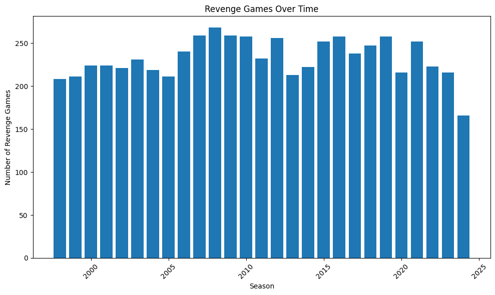

```python
import matplotlib.pyplot as plt

# Group by season and count revenge games
revenge_games_per_season = revenge_players.groupby('season')['player'].count().reset_index()

# Create plot
plt.figure(figsize=(10, 6))
plt.bar(revenge_games_per_season['season'], revenge_games_per_season['player'])
plt.xlabel("Season")
plt.ylabel("Number of Revenge Games")
plt.title("Revenge Games Over Time")
plt.xticks(rotation=45)
plt.tight_layout()
plt.show()
```

This graph shows a pretty similar number of revenge games per season, which seems to hover above ~200 games per season. I was curious to see if this value increased over time suggesting that players were switching teams more often, however that does not appear to be the case.

- Net rating is an advanced stat calculated by subtracting the defensive rating from the offensive rating
- Where Offensive rating = 100*(points/possession)
- Defensive rating = 100*(opponents points/opponents possessions)
- Pie or Player Impact Estimate is an advanced stat created to compile all counting stats for a player into 1 comprehensive statistic
- PIE =(PTS + FGM + FTM – FGA – FTA + Deff.REB + Off.REB/2 + AST + STL + BLK/2 – PF – TO) / (Game.PTS + Game.FGM + Game.FTM – Game.FGA – Game.FTA + Game.Deff.REB + Game.Off.REB/2 + Game.AST + Game.STL + Game.BLK/2 – Game.PF – Game.TO)

```
Average net rating of players: -2.742509693796296
Average net rating of players in revenge games: -1.5694251249288724
Average PIE of players: 8.282525489890174
Average PIE of players in revenge games: 8.999737332495528
```

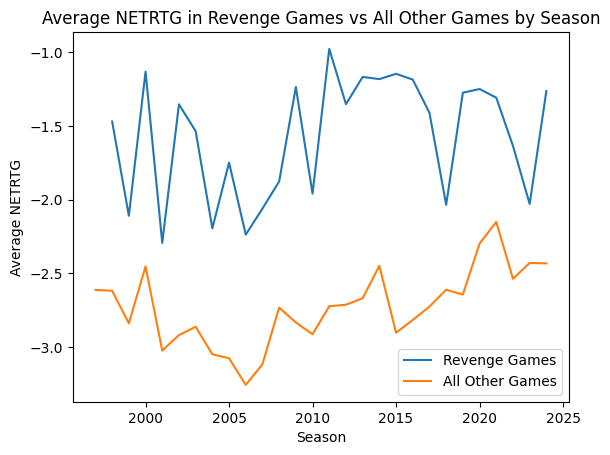

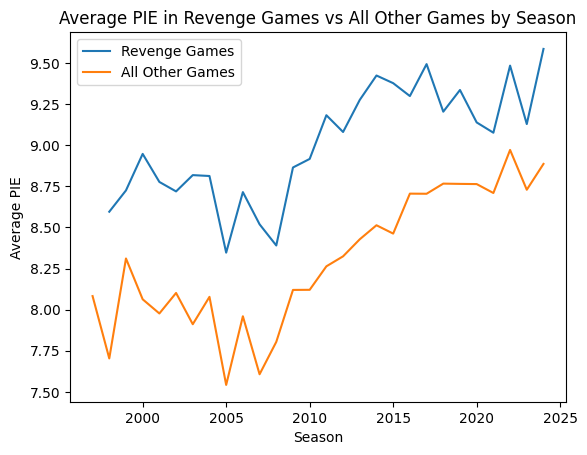

```python
import matplotlib.pyplot as plt

# Calculate average points scored
avg_net = merged_df['NETRTG'].mean()

# Print the result
print(f"Average net rating of players: {avg_net}")

# Calculate average points in revenge games
avg_net1 = revenge_games['NETRTG'].mean()

# Print the result
print(f"Average net rating of players in revenge games: {avg_net1}")

# Calculate average points scored
avg_pie = merged_df['PIE'].mean()

# Print the result
print(f"Average PIE of players: {avg_pie}")

# Calculate average points in revenge games
avg_pie1 = revenge_games['PIE'].mean()

# Print the result
print(f"Average PIE of players in revenge games: {avg_pie1}")

# Get a list of player_game_ids for revenge games
revenge_game_ids = revenge_games.index

# Filter merged_df to exclude revenge games
all_games_excluding_revenge = merged_df[~merged_df.index.isin(revenge_game_ids)]

# Calculate average NETRTG for revenge games by season
avg_netrtg_revenge_by_season = revenge_games.groupby('season')['NETRTG'].mean()

# Calculate average NETRTG for all other games by season
avg_netrtg_all_excluding_revenge_by_season = all_games_excluding_revenge.groupby('season')['NETRTG'].mean()

# Create the graph
plt.plot(avg_netrtg_revenge_by_season.index, avg_netrtg_revenge_by_season.values, label='Revenge Games')
plt.plot(avg_netrtg_all_excluding_revenge_by_season.index, avg_netrtg_all_excluding_revenge_by_season.values, label='All Other Games')
plt.xlabel('Season')
plt.ylabel('Average NETRTG')
plt.title('Average NETRTG in Revenge Games vs All Other Games by Season')
plt.legend()
plt.show()


# Calculate average PIE for revenge games by season
avg_pie_revenge_by_season = revenge_games.groupby('season')['PIE'].mean()

# Calculate average PIE for all other games by season
avg_pie_all_excluding_revenge_by_season = all_games_excluding_revenge.groupby('season')['PIE'].mean()

plt.plot(avg_pie_revenge_by_season.index, avg_pie_revenge_by_season.values, label='Revenge Games')
plt.plot(avg_pie_all_excluding_revenge_by_season.index, avg_pie_all_excluding_revenge_by_season.values, label='All Other Games')
plt.xlabel('Season')
plt.ylabel('Average PIE')
plt.title('Average PIE in Revenge Games vs All Other Games by Season')
plt.legend()
plt.show()
```

Assist to turnover ratio is a good measure of a players efficacy on court, and high mins and usage could result in high counting stats(points/assists/rebounds) but is not necessarily indicative of performance if it is also accompanied by a high turnover count.

Usage % is a useful tool to show an increase in players on court usage. This increase could correlate to high counting stats in game.

The calculation for usage percentage is: 100x((Player’s Field Goal Attempts)+0.44x(Player’s Free Throw Attempts)+(Player’s Turnovers))*(Team’s Total Minutes) / ((Team’s Total Field Goal Attempts)+0.44x(Team’s Total Free Throw Attempts)+Team’s Total Turnovers))x5x(Player’s Minutes)

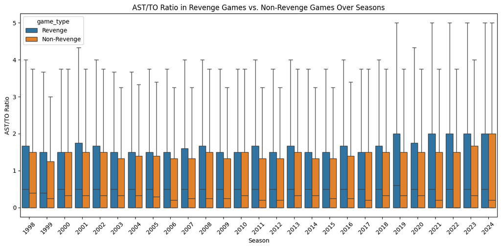

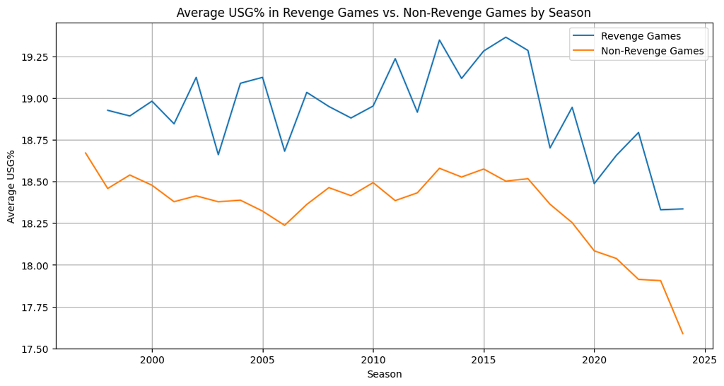

```python
import seaborn as sns

# Filter data for plotting and exclude 1997 season
revenge_game_data = revenge_games[revenge_games['season'] != 1997][['season', 'AST/TO']].replace([np.inf, -np.inf], np.nan).dropna()
non_revenge_game_data = all_games_excluding_revenge[all_games_excluding_revenge['season'] != 1997][['season', 'AST/TO']].replace([np.inf, -np.inf], np.nan).dropna()


# Combine the data into a single DataFrame for plotting
plot_data = pd.concat([
    revenge_game_data.assign(game_type='Revenge'),
    non_revenge_game_data.assign(game_type='Non-Revenge')
])

# Create the box plot using seaborn, hiding outliers
plt.figure(figsize=(12, 6))
sns.boxplot(x='season', y='AST/TO', hue='game_type', data=plot_data, showfliers=False)
plt.xlabel("Season")
plt.ylabel("AST/TO Ratio")
plt.title("AST/TO Ratio in Revenge Games vs. Non-Revenge Games Over Seasons")
plt.xticks(rotation=45)
plt.tight_layout()
plt.show()


# Calculate average USG% for revenge and non-revenge games by season
revenge_usg_by_season = revenge_games.groupby('season')['USG%'].mean()
non_revenge_usg_by_season = all_games_excluding_revenge.groupby('season')['USG%'].mean()

# Create the line graph
plt.figure(figsize=(12, 6))
plt.plot(revenge_usg_by_season.index, revenge_usg_by_season.values, label='Revenge Games')
plt.plot(non_revenge_usg_by_season.index, non_revenge_usg_by_season.values, label='Non-Revenge Games')
plt.xlabel('Season')
plt.ylabel('Average USG%')
plt.title('Average USG% in Revenge Games vs. Non-Revenge Games by Season')
plt.legend()
plt.grid(True)
plt.show()
```

We now have 4 separate comparisons showing, higher assists/turnover, higher Player Impact Estimate, higher Net Rating, and higher usage% in revenge games. All of the data for the graphs was created using regular season games with revenge games removed contrasted with the revenge game instances.

From the above analysis there is now a strong correlation between increased performance and revenge games, but now can we use this data to predict how players will perform in revenge games. Specific games will have way too high variance and other variables to be able to accurately predict individual outcomes. If we were to look at entire season outcomes this should remove a significant amount of variance.

If we remove the 2024 season from the data set and then calculate % change in certain statistics in revenge games would we be able to use those same deltas to accurately predict what the outcomes in those categories were in the 2024 season based on the baseline stats recorded for that season were

```python
# Remove the 2024 season from our existing data frames for revenege and non-revenge game data
revenge_game_no_2024 = revenge_games[revenge_games['season'] != 2024]
non_revenge_game_no_2024 = all_games_excluding_revenge[all_games_excluding_revenge['season'] != 2024]

# Calculate average stats for non-revenge games (excluding 2024)
avg_stats_non_revenge = non_revenge_game_no_2024[['PTS', 'REB', 'AST']].mean()

# Calculate average stats for revenge games (excluding 2024)
avg_stats_revenge = revenge_game_no_2024[['PTS', 'REB', 'AST']].mean()

# Calculate percentage change
percentage_change = ((avg_stats_revenge - avg_stats_non_revenge) / avg_stats_non_revenge) * 100

# Print the results
print("Percentage change in stats between revenge games and non-revenge games (excluding 2024):")
print(percentage_change)
```

```
Percentage change in stats between revenge games and non-revenge games (excluding 2024):
PTS    12.579186
REB     9.748717
AST    11.269285
dtype: float64
```

Now that we have the percentage change in stats between revenge games and non-revenge games can we use this data to predict the outcomes of the 2024 season.

```python
# Select the 2024 season from our existing data frames for revenege and non-revenge game data
revenge_game_2024 = revenge_games[revenge_games['season'] == 2024]
non_revenge_game_2024 = all_games_excluding_revenge[all_games_excluding_revenge['season'] == 2024]

# Calculate average stats for non-revenge games for 2024
avg_stats_non_revenge_2024 = non_revenge_game_2024[['PTS', 'REB', 'AST']].mean()

# Calculate average stats for revenge games for 2024
avg_stats_revenge_2024 = revenge_game_2024[['PTS', 'REB', 'AST']].mean()

# Calculate predicted values using percentage change
predicted_values = avg_stats_non_revenge_2024 * (1 + (percentage_change / 100))

# Print the results
print("Predicted values for revenge games in 2024:")
print(predicted_values)

# Now what were the actual values of revenge games in 2024
print("Actual values for revenge games in 2024:")
actual_values = revenge_game_2024[['PTS', 'REB', 'AST']].mean()
print(actual_values)

# Calculate percentage difference
percentage_difference = ((predicted_values - actual_values) / actual_values) * 100

# Print the results
print("Percentage difference between predicted and actual values for revenge games in 2024:")
print(percentage_difference)
```

```
Predicted values for revenge games in 2024:
PTS    11.478343
REB     4.347549
AST     2.769743
dtype: float64
Actual values for revenge games in 2024:
PTS    11.653683
REB     4.475801
AST     2.748355
dtype: float64
Percentage difference between predicted and actual values for revenge games in 2024:
PTS   -1.504587
REB   -2.865460
AST    0.778197
dtype: float64
```

Now to use a linear regression model to try and predict the average points in revenge games for the 2024 season.

```python
from sklearn.linear_model import LinearRegression
from sklearn.model_selection import train_test_split
from sklearn.metrics import mean_squared_error

# Combine the dataframes and add a target variable using .loc
all_data = pd.concat([revenge_game_data_no_2024, non_revenge_game_data_no_2024])
all_data.loc[all_data.index.isin(revenge_game_data_no_2024.index), 'is_revenge'] = 1
all_data.loc[all_data.index.isin(non_revenge_game_data_no_2024.index), 'is_revenge'] = 0


# Reset index to avoid potential issues
all_data = all_data.reset_index(drop=True)

# Select features and target variable
features = ['is_revenge']
target = 'PTS'

# Split data into training and testing sets
X_train, X_test, y_train, y_test = train_test_split(
    all_data[features], all_data[target], test_size=0.2, random_state=42
)

# Create and train the model
model = LinearRegression()
model.fit(X_train, y_train)

# Make predictions on the test set
y_pred = model.predict(X_test)

# Evaluate the model
mse = mean_squared_error(y_test, y_pred)
print(f"Mean Squared Error: {mse}")


# Prepare the data for 2024
data_2024 = revenge_games[revenge_games['season'] == 2024].copy()

# Add the 'is_revenge' column to data_2024 using .loc
data_2024.loc[:, 'is_revenge'] = 1

X_2024 = data_2024[features]

# Predict the outcomes for 2024 - Check if X_2024 is empty
if X_2024.empty:
    print("No revenge games found in 2024 for prediction.")
else:
    predicted_2024 = model.predict(X_2024)

    # Calculate the average predicted values for PTS
    predicted_avg_pts = predicted_2024.mean()

    # Calculate the actual average values for PTS
    actual_avg_pts = data_2024['PTS'].mean()

    # Compare the predicted and actual values
    print(f"Predicted average points: {predicted_avg_pts}")
    print(f"Actual average points: {actual_avg_pts}")

    # Calculate percentage difference
    percentage_difference_pts = ((predicted_avg_pts - actual_avg_pts) / actual_avg_pts) * 100

    # Print the percentage differences
    print(f"Percentage difference in points: {percentage_difference_pts:.2f}%")
```

```
Mean Squared Error: 65.20375389854283
Predicted average points: 10.918823411442931
Actual average points: 11.653682869879006
Percentage difference in points: -6.31%
```

```python
%%shell
jupyter nbconvert --to html /content/drive/MyDrive/Colab\ Notebooks/Project-Cwinkle.ipynb
```

```
[NbConvertApp] Converting notebook /content/drive/MyDrive/Colab Notebooks/Project-Cwinkle.ipynb to html
[NbConvertApp] Writing 386426 bytes to /content/drive/MyDrive/Colab Notebooks/Project-Cwinkle.html
```